# Evidencia 2: Proyecto Integrador

Amy Vanesa Díaz García-A01656419

2022-05-05

## Coronavirus de otras especies que son similares a SARS-CoV-2

**Calcular la longitud de las secuencias que incluyas.**

**1. Apodemus chevrieri coronavirus**

```r
library("seqinr")

apo<- read.fasta("C:/Users/tete_/OneDrive/Escritorio/Amy/ApodemusChevrieri.fasta")

length(apo[[1]])
```

```
## [1] 27682
```

**2. Bat coronavirus**

```r
library("seqinr")

bat<- read.fasta("C:/Users/tete_/OneDrive/Escritorio/Amy/bat.fasta")

length(bat[[1]])
```

```
## [1] 30488
```

**3.Canine respiratory coronavirus**

```r
library("seqinr")

canine<- read.fasta("C:/Users/tete_/OneDrive/Escritorio/Amy/Canine respiratory.fasta")

length(canine[[1]])
```

```
## [1] 30868
```

**4.Duck coronavirus**

```r
library("seqinr")

duck <- read.fasta("C:/Users/tete_/OneDrive/Escritorio/Amy/Duck.fasta")

length(duck[[1]])
```

```
## [1] 27673
```

**5.Erinaceus hedgehog coronavirus**

```r
library("seqinr")

erin<- read.fasta("C:/Users/tete_/OneDrive/Escritorio/Amy/Erinaceus.fasta")

length(erin[[1]])
```

```
## [1] 29951
```

**6.Hypsugo bat coronavirus**

```r
library("seqinr")

hyp<- read.fasta("C:/Users/tete_/OneDrive/Escritorio/Amy/Hypsugo bat.fasta")

length(hyp[[1]])
```

```
## [1] 30498
```

**7.Lucheng Rn rat coronavirus**

```r
library("seqinr")

luch<- read.fasta("C:/Users/tete_/OneDrive/Escritorio/Amy/Lucheng Rat.fasta")

length(luch[[1]])
```

```
## [1] 28763
```

**8.Miniopterus fulignosus bat coronavirus**

```r
library("seqinr")

mini<- read.fasta("C:/Users/tete_/OneDrive/Escritorio/Amy/Miniopterus bat.fasta")

length(mini[[1]])
```

```
## [1] 28758
```

**9.Myotis ricketti bat coronavirus**

```r
library("seqinr")

myo<- read.fasta("C:/Users/tete_/OneDrive/Escritorio/Amy/Myotis bat.fasta")

length(myo[[1]])
```

```
## [1] 27935
```

**10.Night-heron coronavirus HKU19**

```r
library("seqinr")

night<- read.fasta("C:/Users/tete_/OneDrive/Escritorio/Amy/Night-heron.fasta")

length(night[[1]])
```

```
## [1] 26077
```

**11.Pheasant coronavirus**

```r
library("seqinr")

phe<- read.fasta("C:/Users/tete_/OneDrive/Escritorio/Amy/Pheasant.fasta")

length(phe[[1]])
```

```
## [1] 27655
```

**12.Pipistrellus abramus bat coronavirus**

```r
library("seqinr")

pipi<- read.fasta("C:/Users/tete_/OneDrive/Escritorio/Amy/Pipistrellus bat.fasta")

length(pipi[[1]])
```

```
## [1] 30480
```

**13.Porcine hemagglutinating encephalomyelitis virus**

```r
library("seqinr")

porcine<- read.fasta("C:/Users/tete_/OneDrive/Escritorio/Amy/Porcine.fasta")

length(porcine[[1]])
```

```
## [1] 30684
```

**14.Porcine epidemic diarrhea virus**

```r
library("seqinr")

pdiarrhea<- read.fasta("C:/Users/tete_/OneDrive/Escritorio/Amy/Porcine diarrhea.fasta")

length(pdiarrhea[[1]])
```

```
## [1] 28124
```

**15.Rabbit coronavirus**

```r
library("seqinr")

rabbit<- read.fasta("C:/Users/tete_/OneDrive/Escritorio/Amy/Rabbit.fasta")

length(rabbit[[1]])
```

```
## [1] 31116
```

**16.Sparrow coronavirus**

```r
library("seqinr")

sparrow<- read.fasta("C:/Users/tete_/OneDrive/Escritorio/Amy/Sparrow.fasta")

length(sparrow[[1]])
```

```
## [1] 26083
```

**17.Transmissible gastroenteritis virus**

```r
library("seqinr")

trans<- read.fasta("C:/Users/tete_/OneDrive/Escritorio/Amy/Transmissible.fasta")

length(trans[[1]])
```

```
## [1] 28614
```

**18.White-eye coronavirus HKU16**

```r
library("seqinr")

wEye<- read.fasta("C:/Users/tete_/OneDrive/Escritorio/Amy/white-eye.fasta")

length(wEye[[1]])
```

```
## [1] 26041
```

**19.Wigeon coronavirus**

```r
library("seqinr")

wig<- read.fasta("C:/Users/tete_/OneDrive/Escritorio/Amy/Wigeon.fasta")

length(wig[[1]])
```

```
## [1] 26227
```

**20.Yak coronavirus**

```r
library("seqinr")

yak<- read.fasta("C:/Users/tete_/OneDrive/Escritorio/Amy/yak.fasta")

length(yak[[1]])
```

```
## [1] 31032
```

**Crea una sola gráfica donde se comparen el número de bases de ADN que componen todas las variables del virus.**

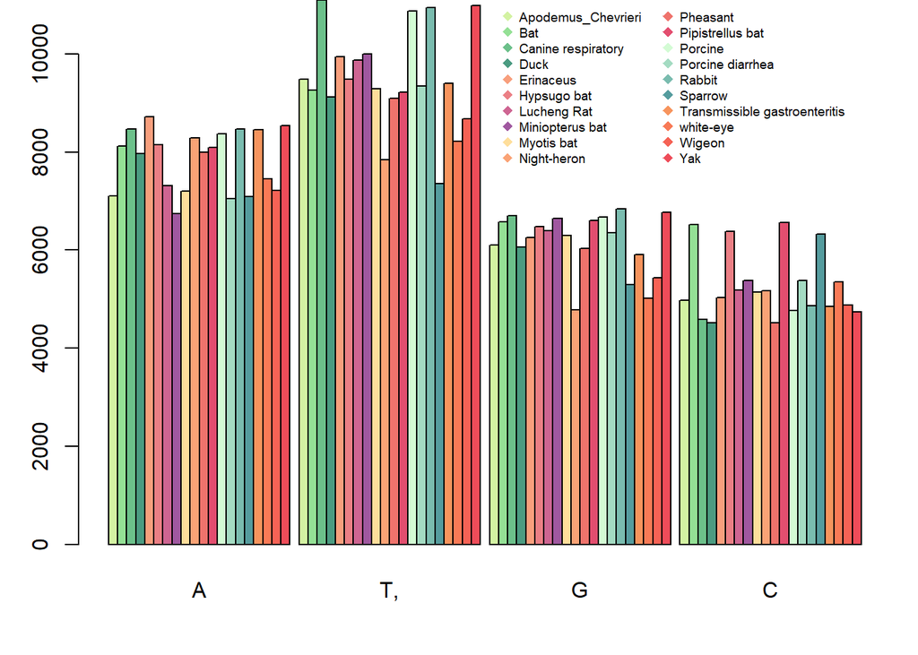

```r
cuentas <- function(seq){
  contadorA <-0
  contadorT <-0
  contadorC <-0
  contadorG <-0

  nl <- length(seq)

  for(i in seq){

    if(i=="A" || i=="a"){
      contadorA = contadorA + 1
    }
    else if(i=="T" || i=="t") {
      contadorT = contadorT + 1
    }
    else if(i=="C" || i=="c") {
      contadorC = contadorC + 1
    }
    else if(i=="G" || i=="g") {
      contadorG = contadorG + 1
    }
  }

  vec<- c(contadorA,contadorT,contadorG, contadorC)
  return(vec)
}

colorPalette<- c('#D3F2A2','#94E095','#6CC08A', '#4B9B81','#F89F7D', '#EB7F85','#CE6592','#A058A0','#FEDE9B', '#FAA376','#EF736C','#E34E6F','#D3FBD4', '#A4DBC2','#7ABCAF','#559C9E','#F7945D', '#F87A56','#F56255','#EE4C59')
colorPalette1<- c('#D3F2A2','#94E095','#6CC08A', '#4B9B81','#F89F7D', '#EB7F85','#CE6592','#A058A0','#FEDE9B', '#FAA376')
colorPalette2<- c('#EF736C','#E34E6F','#D3FBD4', '#A4DBC2','#7ABCAF','#559C9E','#F7945D', '#F87A56','#F56255','#EE4C59')


virusNames1<-c("Apodemus_Chevrieri","Bat", "Canine respiratory", "Duck", "Erinaceus","Hypsugo bat","Lucheng Rat","Miniopterus bat", "Myotis bat","Night-heron")
virusNames2<- c("Pheasant","Pipistrellus bat","Porcine","Porcine diarrhea","Rabbit", "Sparrow", "Transmissible gastroenteritis","white-eye","Wigeon","Yak")

funG<- c(APO<-sapply(apo, cuentas),BAT<-sapply(bat, cuentas),CANIN<-sapply(canine, cuentas),DUCK<-sapply(duck, cuentas),ERIN<-sapply(erin, cuentas),HYP<-sapply(hyp, cuentas),LUNCH<-sapply(luch, cuentas),MINI<-sapply(mini, cuentas),MYO<-sapply(myo, cuentas),NIGHT<-sapply(night, cuentas),PHE<-sapply(phe, cuentas),PIPI<-sapply(pipi, cuentas),PORCINE<-sapply(porcine, cuentas),PDIARRHEA<-sapply(pdiarrhea, cuentas),RABBIT<-sapply(rabbit, cuentas),SPARROW<-sapply(sparrow, cuentas),TRANS<-sapply(trans, cuentas),WEYE<-sapply(wEye, cuentas),WIG<-sapply(wig, cuentas),YAK<-sapply(yak, cuentas))



par(mar=c(4,3,0,1))
virus<-barplot(matrix(c(funG), nrow=20, byrow=T), beside=T,  col = colorPalette, names.arg= c("A","T,","G", "C"))
legend("topright", legend = virusNames1 ,
     col = colorPalette1 ,bty = "n", pch=18 , pt.cex = 1, cex = 0.6, horiz = FALSE, inset = c(0.3, 0.001))
legend("topright", legend = virusNames2 ,
     col = colorPalette2 ,bty = "n", pch=18 , pt.cex = 1, cex = 0.6, horiz = FALSE, inset = c(0.05, 0.001))
```

**Agrega un análisis jerárquico global obtenido de las secuencias que se seleccionaron para estudiar.**

```r
library(Biostrings)
library(seqinr)
library(adegenet)
library(ape)
library(ggtree)
library(DECIPHER)
library(viridis)
```

```r
library(ggplot2)
```

```r
ANIMALES <- c(  "NC_034972", "EF065511", "KX432213", "JF705860", "MK907287", "KX442564", "KF294380", "KJ473797", "KJ473806", "NC_016994", "MK423876", "KJ473820", "KY994645", "KX981440", "JN874560", "NC_016992", "KX499468", "JQ065044", "NC_016995", "MH810163")

virus_sequences <- read.GenBank(ANIMALES)

str(virus_sequences)
```

```
## List of 20
##  $ NC_034972: raw [1:27682] 88 48 88 88 ...
##  $ EF065511 : raw [1:30488] 48 88 18 18 ...
##  $ KX432213 : raw [1:30868] 88 88 28 18 ...
##  $ JF705860 : raw [1:27673] 88 28 18 18 ...
##  $ MK907287 : raw [1:29951] 48 88 18 18 ...
##  $ KX442564 : raw [1:30498] 48 88 18 18 ...
##  $ KF294380 : raw [1:28763] 88 28 18 18 ...
##  $ KJ473797 : raw [1:28758] 18 48 88 28 ...
##  $ KJ473806 : raw [1:27935] 48 88 28 18 ...
##  $ NC_016994: raw [1:26077] 48 88 28 88 ...
##  $ MK423876 : raw [1:27655] 88 28 18 88 ...
##  $ KJ473820 : raw [1:30480] 48 88 18 18 ...
##  $ KY994645 : raw [1:30684] 48 88 18 18 ...
##  $ KX981440 : raw [1:28124] 48 88 18 18 ...
##  $ JN874560 : raw [1:31116] 48 88 18 18 ...
##  $ NC_016992: raw [1:26083] 48 48 18 88 ...
##  $ KX499468 : raw [1:28614] 88 28 18 18 ...
##  $ JQ065044 : raw [1:26041] 48 88 28 88 ...
##  $ NC_016995: raw [1:26227] 48 18 28 88 ...
##  $ MH810163 : raw [1:31032] 48 88 18 18 ...
##  - attr(*, "class")= chr "DNAbin"
##  - attr(*, "description")= chr [1:20] "NC_034972.1 Coronavirus AcCoV-JC34, complete genome" "EF065511.1 Bat coronavirus HKU5-3, complete genome" "KX432213.1 Canine respiratory coronavirus strain BJ232, complete genome" "JF705860.1 Duck coronavirus isolate DK/CH/HN/ZZ2004, complete genome" ...
##  - attr(*, "species")= chr [1:20] "Coronavirus_AcCoV-JC34" "Bat_coronavirus_HKU5-3" "Canine_respiratory_coronavirus" "Duck_coronavirus" ...
```

```r
attributes(virus_sequences)
```

```
## $names
##  [1] "NC_034972" "EF065511"  "KX432213"  "JF705860"  "MK907287"  "KX442564"
##  [7] "KF294380"  "KJ473797"  "KJ473806"  "NC_016994" "MK423876"  "KJ473820"
## [13] "KY994645"  "KX981440"  "JN874560"  "NC_016992" "KX499468"  "JQ065044"
## [19] "NC_016995" "MH810163"
##
## $class
## [1] "DNAbin"
##
## $description
##  [1] "NC_034972.1 Coronavirus AcCoV-JC34, complete genome"
##  [2] "EF065511.1 Bat coronavirus HKU5-3, complete genome"
##  [3] "KX432213.1 Canine respiratory coronavirus strain BJ232, complete genome"
##  [4] "JF705860.1 Duck coronavirus isolate DK/CH/HN/ZZ2004, complete genome"
##  [5] "MK907287.1 Erinaceus hedgehog coronavirus HKU31 strain Rs13, complete genome"
```

[output cut: 37 more lines]

```r
names(virus_sequences)
```

```
##  [1] "NC_034972" "EF065511"  "KX432213"  "JF705860"  "MK907287"  "KX442564"
##  [7] "KF294380"  "KJ473797"  "KJ473806"  "NC_016994" "MK423876"  "KJ473820"
## [13] "KY994645"  "KX981440"  "JN874560"  "NC_016992" "KX499468"  "JQ065044"
## [19] "NC_016995" "MH810163"
```

```r
attr(virus_sequences, "species")
```

```
##  [1] "Coronavirus_AcCoV-JC34"
##  [2] "Bat_coronavirus_HKU5-3"
##  [3] "Canine_respiratory_coronavirus"
##  [4] "Duck_coronavirus"
##  [5] "Erinaceus_hedgehog_coronavirus_HKU31"
##  [6] "Hypsugo_bat_coronavirus_HKU25"
##  [7] "Lucheng_Rn_rat_coronavirus"
##  [8] "BtMf-AlphaCoV/GD2012"
##  [9] "BtMr-AlphaCoV/SAX2011"
## [10] "Night_heron_coronavirus_HKU19"
## [11] "Pheasant_coronavirus"
## [12] "BtPa-BetaCoV/GD2013"
## [13] "Porcine_hemagglutinating_encephalomyelitis_virus"
## [14] "Porcine_epidemic_diarrhea_virus"
## [15] "Rabbit_coronavirus_HKU14"
## [16] "Sparrow_coronavirus_HKU17"
## [17] "Transmissible_gastroenteritis_virus"
## [18] "White-eye_coronavirus_HKU16"
## [19] "Wigeon_coronavirus_HKU20"
## [20] "Yak_coronavirus"
```

```r
write.dna(virus_sequences,
          file ="virus_seqs.fasta",
          format = "fasta",
          append = FALSE,
          nbcol = 6,
          colsep = " ",
          colw = 10)

virus_seq_not_align <- readDNAStringSet("virus_seqs.fasta", format = "fasta")
virus_seq_not_align <- OrientNucleotides(virus_seq_not_align)
```

```
## ========================================================================================================================================================================================================
##
## Time difference of 0.21 secs
```

```r
virus_seq_align <- AlignSeqs(virus_seq_not_align)
```

[output not shown]

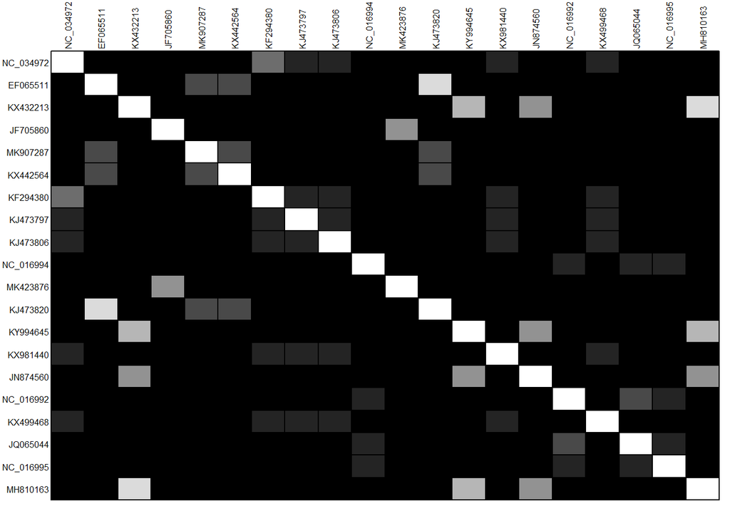

```r
BrowseSeqs(virus_seq_align, highlight=0)

writeXStringSet(virus_seq_align, file="virus_seq_align.fasta")

virus_aligned <- read.alignment("virus_seq_align.fasta", format = "fasta")

matriz_distancia <- dist.alignment(virus_aligned, matrix = "similarity")

temp <- as.data.frame(as.matrix(matriz_distancia))
table.paint(temp, cleg=0, clabel.row=.5, clabel.col=.5) + scale_color_viridis()
```

```r
virus_tree <- nj(matriz_distancia)
class(virus_tree)
```

```
## [1] "phylo"
```

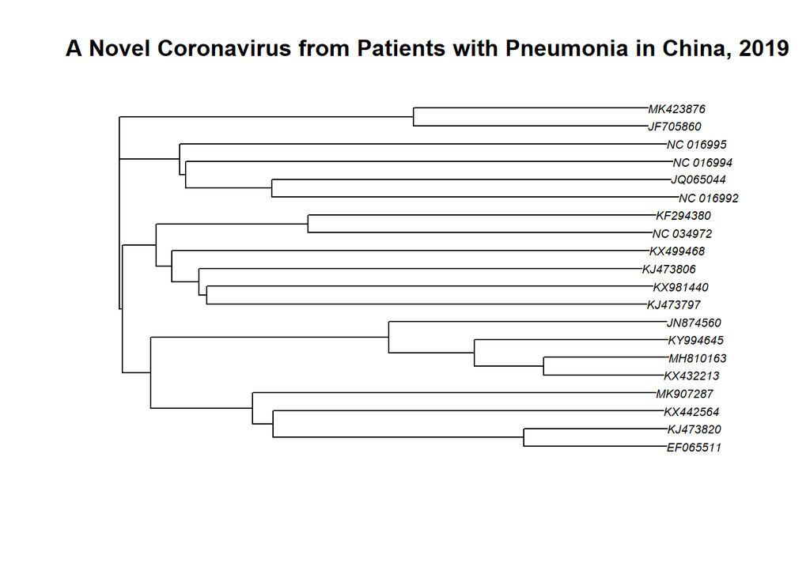

```r
virus_tree <- ladderize(virus_tree)

plot(virus_tree, cex = 0.6)
title("A Novel Coronavirus from Patients with Pneumonia in China, 2019")
```

**Interpretación**

Con el árbol filogenético presentado anteriormente podemos llegar a diversas conclusiones, una de ellas es que Canine respiratory coronavirus y Yak coronavirus son muy similares ya que estén dentro de la misma rama y en el mismo nivel podemos encontrar Porcine hemagglutinating encephalomyelitis virus. Algo muy interesante es que Pheasant coronavirus y Duck coronavirus son los únicos que comparten un ancestro en común que derivan en los diferentes códigos , pero aún así tienen una base igual.

**Referencias bibliográficas**

Haake C, Cook S, Pusterla N, Murphy B. Coronavirus Infections in Companion Animals: Virology, Epidemiology, Clinical and Pathologic Features. Viruses. 2020 Sep 13;12(9):1023. doi: 10.3390/v12091023. PMID: 32933150; PMCID: PMC7551689

Li, C., Yang, Y., & Ren, L. (2020). Genetic evolution analysis of 2019 novel coronavirus and coronavirus from other species. Infection, genetics and evolution : journal of molecular epidemiology and evolutionary genetics in infectious diseases, 82, 104285. https://doi.org/10.1016/j.meegid.2020.104285

**Link video** https://youtu.be/sHrRzQqFGUg

## Citas paquetes de R

```r
citation("dplyr")
```

```
##
##
##   Wickham H, François R, Henry L, Müller K (2022). _dplyr: A Grammar of
##   Data Manipulation_. R package version 1.0.9,
##   <https://CRAN.R-project.org/package=dplyr>.
##
## A BibTeX entry for LaTeX users is
##
##   @Manual{,
##     title = {dplyr: A Grammar of Data Manipulation},
##     author = {Hadley Wickham and Romain François and Lionel Henry and Kirill Müller},
##     year = {2022},
##     note = {R package version 1.0.9},
##     url = {https://CRAN.R-project.org/package=dplyr},
##   }
```

```r
citation("Biostrings")
```

```
##
##
##   Pagès H, Aboyoun P, Gentleman R, DebRoy S (2022). _Biostrings:
##   Efficient manipulation of biological strings_. R package version
##   2.64.0, <https://bioconductor.org/packages/Biostrings>.
##
## A BibTeX entry for LaTeX users is
##
##   @Manual{,
##     title = {Biostrings: Efficient manipulation of biological strings},
##     author = {H. Pagès and P. Aboyoun and R. Gentleman and S. DebRoy},
##     year = {2022},
##     note = {R package version 2.64.0},
##     url = {https://bioconductor.org/packages/Biostrings},
##   }
##
## ATTENTION: This citation information has been auto-generated from the
## package DESCRIPTION file and may need manual editing, see
## 'help("citation")'.
```

```r
citation("seqinr")
```

```
##
##
##   Charif, D. and Lobry, J.R. (2007)
##
## A BibTeX entry for LaTeX users is
##
##   @InCollection{,
##     author = {D. Charif and J.R. Lobry},
##     title = {Seqin{R} 1.0-2: a contributed package to the {R} project for statistical computing devoted to biological sequences retrieval and analysis.},
##     booktitle = {Structural approaches to sequence evolution: Molecules, networks, populations},
##     year = {2007},
##     editor = {U. Bastolla and M. Porto and H.E. Roman and M. Vendruscolo},
##     series = {Biological and Medical Physics, Biomedical Engineering},
##     pages = {207-232},
##     address = {New York},
##     publisher = {Springer Verlag},
##     note = {{ISBN :} 978-3-540-35305-8},
##   }
```

```r
citation("adegenet")
```

```
##
##
##   Jombart, T. (2008) adegenet: a R package for the multivariate
##   analysis of genetic markers. Bioinformatics 24: 1403-1405. doi:
##   10.1093/bioinformatics/btn129
##
##   Jombart T. and Ahmed I. (2011) adegenet 1.3-1: new tools for the
##   analysis of genome-wide SNP data. Bioinformatics. doi:
##   10.1093/bioinformatics/btr521
##
## To see these entries in BibTeX format, use 'print(<citation>,
## bibtex=TRUE)', 'toBibtex(.)', or set
## 'options(citation.bibtex.max=999)'.
```

```r
citation("ape")
```

```
##
##
##   Paradis E. & Schliep K. 2019. ape 5.0: an environment for modern
##   phylogenetics and evolutionary analyses in R. Bioinformatics 35:
##   526-528.
##
## A BibTeX entry for LaTeX users is
##
##   @Article{,
##     title = {ape 5.0: an environment for modern phylogenetics and evolutionary analyses in {R}},
##     author = {E. Paradis and K. Schliep},
##     journal = {Bioinformatics},
##     year = {2019},
##     volume = {35},
##     pages = {526-528},
##   }
##
## As ape is evolving quickly, you may want to cite also its version
## number (found with 'library(help = ape)' or 'packageVersion("ape")').
```

```r
citation("phangorn")
```

```
##
## Use 2011 to cite phangorn in a publication; 2017 for plotting
## phylogenetic networks. As phangorn is evolving quickly, you may want to
## cite also its version number (phangorn 2.8.1).
##
##   Schliep K.P. 2011. phangorn: phylogenetic analysis in R.
##   Bioinformatics, 27(4) 592-593
##
##   Schliep, K., Potts, A. J., Morrison, D. A., Grimm, G. W. (2017),
##   Intertwining phylogenetic trees and networks. Methods in Ecology and
##   Evolution, 8: 1212--1220. doi: 10.1111/2041-210X.12760
##
## To see these entries in BibTeX format, use 'print(<citation>,
## bibtex=TRUE)', 'toBibtex(.)', or set
## 'options(citation.bibtex.max=999)'.
```

```r
citation("phytools")
```

```
##
##
##   Revell, L. J. (2012) phytools: An R package for phylogenetic
##   comparative biology (and other things). Methods Ecol. Evol. 3
##   217-223. doi:10.1111/j.2041-210X.2011.00169.x
##
## A BibTeX entry for LaTeX users is
##
##   @Article{,
##     title = {phytools: An R package for phylogenetic comparative biology (and other things).},
##     author = {Liam J. Revell},
##     journal = {Methods in Ecology and Evolution},
##     year = {2012},
##     volume = {3},
##     pages = {217-223},
##   }
##
## As phytools is continually evolving, you may want to cite its version
## number. Find it with 'help(package=phytools)'.
```

```r
citation("geiger")
```

```
##
##
## medusa
##
##   Alfaro Michael E, Francesco Santini, Chad Brock, Hugo Alamillo, Alex
##   Dornburg, Daniel L Rabosky, Giorgio Carnevale, and Luke J Harmon.
##   2009. Nine exceptional radiations plus high turnover explain species
##   diversity in jawed vertebrates. PNAS 106:13410-13414.
##
## auteur
##
##   Eastman Jonathan M, Michael E Alfaro, Paul Joyce, Andrew L Hipp, and
##   Luke J Harmon. 2011. A novel comparative method for identifying
##   shifts in the rate of character evolution on trees. Evolution
##   65:3578-3589.
##
## MECCA
##
##   Slater Graham J, Luke J Harmon, Daniel Wegmann, Paul Joyce, Liam J
##   Revell, and Michael E Alfaro. 2012. Fitting models of continuous
##   trait evolution to incompletely sampled comparative data using
##   approximate Bayesian computation. Evolution 66:752-762.
##
## geiger-orig
##
##   Harmon Luke J, Jason T Weir, Chad D Brock, Richard E Glor, and
##   Wendell Challenger. 2008. GEIGER: investigating evolutionary
##   radiations. Bioinformatics 24:129-131.
##
## geiger
##
##   Pennell Matthew W, Jonathan M Eastman, Graham J Slater, Joseph W
##   Brown, Josef C Uyeda, Richard G FitzJohn, Michael E Alfaro, and Luke
##   J Harmon. 2014. geiger v2.0: an expanded suite of methods for fitting
##   macroevolutionary models to phylogenetic trees. Bioinformatics
##   30:2216-2218.
##
## To see these entries in BibTeX format, use 'print(<citation>,
## bibtex=TRUE)', 'toBibtex(.)', or set
## 'options(citation.bibtex.max=999)'.
```

```r
citation("BiocManager")
```

```
##
##
##   Morgan M (2022). _BiocManager: Access the Bioconductor Project
##   Package Repository_. R package version 1.30.17,
##   <https://CRAN.R-project.org/package=BiocManager>.
##
## A BibTeX entry for LaTeX users is
##
##   @Manual{,
##     title = {BiocManager: Access the Bioconductor Project Package Repository},
##     author = {Martin Morgan},
##     year = {2022},
##     note = {R package version 1.30.17},
##     url = {https://CRAN.R-project.org/package=BiocManager},
##   }
```

```r
citation("ggtree")
```

```
##
##
##   Guangchuang Yu. Using ggtree to visualize data on tree-like
##   structures. Current Protocols in Bioinformatics, 2020, 69:e96. doi:
##   10.1002/cpbi.96
##
##   Guangchuang Yu, Tommy Tsan-Yuk Lam, Huachen Zhu, Yi Guan. Two methods
##   for mapping and visualizing associated data on phylogeny using
##   ggtree. Molecular Biology and Evolution 2018, 35(2):3041-3043. doi:
##   10.1093/molbev/msy194
##
##   Guangchuang Yu, David Smith, Huachen Zhu, Yi Guan, Tommy Tsan-Yuk
##   Lam. ggtree: an R package for visualization and annotation of
##   phylogenetic trees with their covariates and other associated data.
##   Methods in Ecology and Evolution 2017, 8(1):28-36.
##   doi:10.1111/2041-210X.12628
##
## To see these entries in BibTeX format, use 'print(<citation>,
## bibtex=TRUE)', 'toBibtex(.)', or set
## 'options(citation.bibtex.max=999)'.
```

```r
citation("DECIPHER")
```

```
##
##
##   Wright ES (2016). "Using DECIPHER v2.0 to Analyze Big Biological
##   Sequence Data in R." _The R Journal_, *8*(1), 352-359.
##
## A BibTeX entry for LaTeX users is
##
##   @Article{,
##     title = {Using DECIPHER v2.0 to Analyze Big Biological Sequence Data in R},
##     author = {Erik S. Wright},
##     journal = {The R Journal},
##     year = {2016},
##     volume = {8},
##     number = {1},
##     pages = {352-359},
##   }
```

```r
citation("viridis")
```

[output not shown]

```r
citation("ggplot2")
```

```
##
##
##   H. Wickham. ggplot2: Elegant Graphics for Data Analysis.
##   Springer-Verlag New York, 2016.
##
## A BibTeX entry for LaTeX users is
##
##   @Book{,
##     author = {Hadley Wickham},
##     title = {ggplot2: Elegant Graphics for Data Analysis},
##     publisher = {Springer-Verlag New York},
##     year = {2016},
##     isbn = {978-3-319-24277-4},
##     url = {https://ggplot2.tidyverse.org},
##   }
```